# Final Project - Jack Tonina

Load all necesary packages for project.

```r
library(rvest)
library(jsonlite)
library(stringr)
library(RSQLite)
library(caTools)
library(sqldf)
library(stats)
library(BBmisc)
library(class)
library(caret)
library(gmodels)
library(neuralnet)
```

Read offensive data for each ballpark in from CSV downloaded of website. Removes the three rows below because they are ballparks that hosted exhibition games, and therefore dont have a full season of data, or a team associated with it. Also they are not included in the data containing outfield areas and park dimensions. Renames two of the cells for the ballparks to make alphabetical order of ballparks same as two other datasets. Lastly, orders the dataframe in alphabetical order based on the ballpark column.

```r
parkHomeruns <- read.csv("sportsref_download-4.csv")
parkHomeruns <- parkHomeruns[-c(3, 12, 13),]
parkHomeruns$Split <- as.character(parkHomeruns$Split)
parkHomeruns[2,1] <- "SanFG-AT&T Pk"
parkHomeruns[20,1] <- "SanDP-Petco Pk"
parkHomeruns <- parkHomeruns[order(parkHomeruns$Split),, drop=FALSE]
```

Reads data in front JSON document generated from a custom web scraper (using import.io). Then creates a dataframe from the JSON documeny. Removes the first column because it was a url for each row of data.

```r
file <- "outfieldareadata.json"
jsonFile <- fromJSON(file)
outfieldAreaDF <- as.data.frame(jsonFile)
outfieldAreaDF <- outfieldAreaDF[,-1]
```

Reads data in from XML nodes acquired using Selector Gadget. Each individual chunk of code specifies the node, then converts it from HTML to text. Removes first element from many of the chunks because this is the title of the column found on the website. The left field, center field and right field data was all stored in one column on the website, so I used regular expressions to break out and strip the dimensions of each park into their own vectors. I then take all the vectors and put them in a list and convert the list to a matrix in order to build my dataframe. I then name each of the columns and order the dataframe in ascending alphabetical order. Finally, creates a column that takes the mean of the LF, CF and RF columns for each row in order to get the average fence distance for each stadium.

```r
url <- "https://www.ballparksofbaseball.com/comparisons/"
webpage <- read_html(url)
stadiumNameHTML <- html_nodes(webpage, 'td:nth-child(1)')
stadiumNameData <- html_text(stadiumNameHTML)
stadiumNameData <- stadiumNameData[-1]
teamHTML <- html_nodes(webpage, 'td:nth-child(2)')
teamData <- html_text(teamHTML)
teamData <- teamData[-1]
dimensionsHTML <- html_nodes(webpage, 'td:nth-child(7)')
dimensionsData <- html_text(dimensionsHTML)
dimensionsData <- dimensionsData[-1]
leftfieldData <- str_extract(dimensionsData, "\\d+-L")
leftfieldData <- substr(leftfieldData,1,nchar(leftfieldData)-2)
leftfieldData <- as.numeric(leftfieldData)
centerfieldData <- str_extract(dimensionsData, "\\d+-C")
centerfieldData <- substr(centerfieldData,1,nchar(centerfieldData)-2)
centerfieldData <- as.numeric(centerfieldData)
rightfieldData <- str_extract(dimensionsData, "\\d+-R")
rightfieldData <- substr(rightfieldData,1,nchar(rightfieldData)-2)
rightfieldData <- as.numeric(rightfieldData)
dataList <- c(stadiumNameData, teamData, leftfieldData, centerfieldData, rightfieldData)
dataMatrix <- matrix(dataList, nrow = 30)
ballparkDimsDF <- as.data.frame(dataMatrix)
names(ballparkDimsDF) <- c("Stadium Name", "Team", "Leftfield Depth", "Centerfield Depth", "Rightfield Depth")
ballparkDimsDF <- ballparkDimsDF[order(ballparkDimsDF$Team), , drop=FALSE]
ballparkDimsDF$AvgFenceDist <- (leftfieldData + centerfieldData + rightfieldData) / 3
```

Reads in CSV obtained using the web scraper Data Miner, showing many key statcast statistics for all players with over 120 measured occurences. Similar process to above data^.

```r
statcastDB <- read.csv("statcastData.csv")
statcastDB <- na.omit(statcastDB)
```

Creates a vector of each teams individual abbreviation that will be used as the primary key in each of the data frames for consistency. I then append this vector to the left of each dataframe using cbind(). Lastly, I used merge() to combine the first two data frames and then finally that combination with my third dataframe to create a master dataframe containing a majority of the important information from each stadium (using the team abbreviations as the key).

```r
teamAbrv <- c("ARI", "ATL", "BAL", "BOS", "CHC", "CWS", "CIN", "CLE", "COL", "DET", "HOU", "KC", "LAA", "LAD", "MIA", "MIL", "MIN", "NYM", "NYY", "OAK", "PHI", "PIT", "SD", "SF", "SEA", "STL", "TB", "TEX", "TOR", "WAS")
ballparkDimsDF <- cbind(TeamAbrv = teamAbrv, ballparkDimsDF)
outfieldAreaDF <- cbind(TeamAbrv = teamAbrv, outfieldAreaDF)
parkHomeruns <- cbind(TeamAbrv = teamAbrv, parkHomeruns)
masterDF <- merge(ballparkDimsDF, outfieldAreaDF, by = "TeamAbrv")
masterDF <- merge(masterDF, parkHomeruns, by = "TeamAbrv")
```

Opens, creates and connects to a SQLite database called “baseballDB.” I create four tables: one for each of my three dataframes and then finally one table for the master (combined) dataframe.

```r
dbOpen <- sqldf("attach baseballDB as new")
```

```
Don't need to call dbFetch() for statements, only for queries
```

```r
connect <- dbConnect(RSQLite::SQLite(), "baseballDB")
fillDBhomers <- dbWriteTable(connect, "homeruns", parkHomeruns, overwrite = TRUE)
fillDBoutfieldArea <- dbWriteTable(connect, "OutfieldArea", outfieldAreaDF, overwrite = TRUE)
fillDBparkDims <- dbWriteTable(connect, "ParkDims", ballparkDimsDF, overwrite = TRUE)
fillDBstatcast <- dbWriteTable(connect, "Statcast", statcastDB, overwrite = TRUE)
fillDBmaster <- dbWriteTable(connect, "Master", masterDF, overwrite = TRUE)
```

Plots all of the homerun values found in the masterDF to visually determine outliers. As you can see, there seems to be two outliers from the majority of the data set.

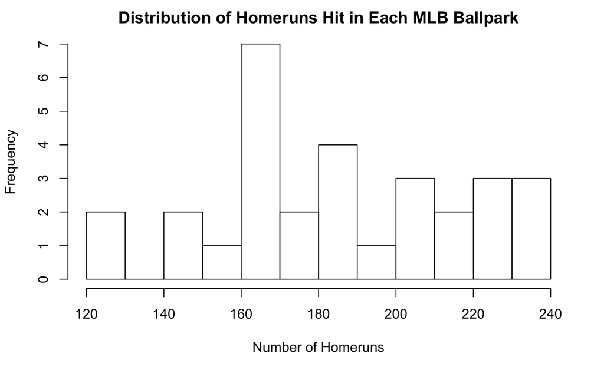

```r
hrOutliers <- hist(masterDF$HR, breaks = 10, main = "Distribution of Homeruns Hit in Each MLB Ballpark", xlab = "Number of Homeruns")
```

Identifies the two outliers found above by connecting to database and pulling information on the two stadiums with the least homeruns. Creates a dataframe with two columns, one for each outlier, showing the stadium name, team, HR hit, outfield depths and finally the rank of the stadium in terms of outfield area (greatest to least).

```r
outlierStadium <- dbGetQuery(connect, 'SELECT "Stadium Name", "TeamAbrv", "HR" FROM Master ORDER BY HR ASC LIMIT 2')
leastHRdims <- dbGetQuery(connect, 'SELECT "Leftfield Depth", "Centerfield Depth", "Rightfield Depth" FROM Master ORDER BY HR ASC LIMIT 2')
outfieldAreaDF$AreaRanks <- rank(-outfieldAreaDF$Of)
minOutlierAreaRank <- paste(outfieldAreaDF[outfieldAreaDF$Stadium == "AT&T Park", 9], "th", sep = "")
min2OutlierAreaRank <- paste(outfieldAreaDF[outfieldAreaDF$Stadium == "Marlins Park", 9], "th", sep = "")
outlier1 <- c(outlierStadium[1,], leastHRdims[1,], minOutlierAreaRank)
outlier2 <- c(outlierStadium[2,], leastHRdims[2,], min2OutlierAreaRank)
twoOutliers <- cbind(outlier1, outlier2)
row.names(twoOutliers) <- c("Stadium", "Team", "HR", "Leftfield Depth", "Centerfield Depth", "Rightfield Depth", "Outfield Area Rank (Greatest to Least)")
print(twoOutliers)
```

```
                                       outlier1    outlier2
Stadium                                "AT&T Park" "Marlins Park"
Team                                   "SF"        "MIA"
HR                                     124         127
Leftfield Depth                        "339"       "340"
Centerfield Depth                      "399"       "420"
Rightfield Depth                       "309"       "335"
Outfield Area Rank (Greatest to Least) "8th"       "6th"
```

Creates a simple plot that shows the correlation between outfield area and number of homeruns hit in that park. As you can, there doesnt seem to be a super strong correlation between these two variables.

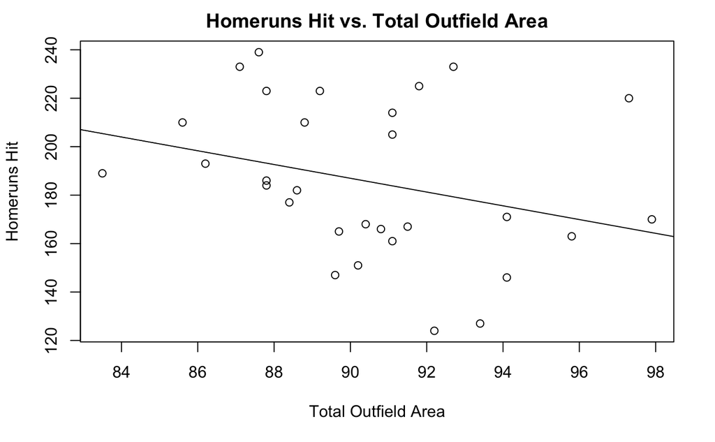

```r
outfieldArea <- masterDF$Of
homerunsHit <- masterDF$HR
regLine <- lm(homerunsHit ~ outfieldArea)
{plot(homerunsHit ~ outfieldArea, ylab = "Homeruns Hit", xlab = "Total Outfield Area", main = "Homeruns Hit vs. Total Outfield Area")
abline(regLine$coefficients)}
```

Looking at the various regression statistics associated with this model, it is clear this isn’t the best predictive model of homeruns hit. Although the regression line makes sense, decreasing in outfield area as more homeruns are hit, the adjusted r-squared value is just .05449 showing minimal fit.

```r
summary(regLine)
```

```
Call:
lm(formula = homerunsHit ~ outfieldArea)

Residuals:
       Min         1Q     Median         3Q        Max
-56.729001 -18.494057  -7.366349  27.605949  53.772190

Coefficients:
               Estimate Std. Error  t value  Pr(>|t|)
(Intercept)  442.887789 157.443972  2.81299 0.0088729 **
outfieldArea  -2.843371   1.739724 -1.63438 0.1133741
---
Signif. codes:  0 ‘***’ 0.001 ‘**’ 0.01 ‘*’ 0.05 ‘.’ 0.1 ‘ ’ 1

Residual standard error: 31.23723 on 28 degrees of freedom
Multiple R-squared:  0.08709144,    Adjusted R-squared:  0.05448757
F-statistic: 2.671199 on 1 and 28 DF,  p-value: 0.1133741
```

Creates model to show the correlations between various Statcast statistics (launch angle, exit velocity, average distance, balls hit harder than 95mph, hard hit percent, barrel percent) and the average homerun distance of players.

```r
statcastDB$Sample <- FALSE
statcastDB$Sample <- sample.split(statcastDB$Sample, SplitRatio = .75)
statcastTrain <- statcastDB[statcastDB$Sample == TRUE, ]
statcastTest <- statcastDB[statcastDB$Sample == FALSE, ]
```

Creates original model, then uses step() to determine the optimal model to predict average homerun distance.

```r
avgHRdistPredictor <- lm(AvgHRdist ~ AvgLaunchAngle + AvgExitVelo + ExitVeloFBLD + AvgDist + HardHit95 + HardHitPct + BarrelPct, data = statcastTrain)
summary(avgHRdistPredictor)
```

```
Call:
lm(formula = AvgHRdist ~ AvgLaunchAngle + AvgExitVelo + ExitVeloFBLD +
    AvgDist + HardHit95 + HardHitPct + BarrelPct, data = statcastTrain)

Residuals:
       Min         1Q     Median         3Q        Max
-33.179759  -5.852105  -0.093812   5.546911  37.368516

Coefficients:
                    Estimate    Std. Error  t value   Pr(>|t|)
(Intercept)    237.427041156  60.849266925  3.90189 0.00012078 ***
AvgLaunchAngle  -0.115398984   0.324354637 -0.35578 0.72228500
AvgExitVelo      0.770056686   0.683751166  1.12622 0.26107836
ExitVeloFBLD     1.275880837   0.530874672  2.40336 0.01692512 *
AvgDist         -0.160893034   0.085263283 -1.88701 0.06023913 .
HardHit95       -0.006068179   0.014215015 -0.42689 0.66980570
HardHitPct      -0.131216907   0.248140557 -0.52880 0.59738136
BarrelPct        0.970583466   0.325513443  2.98170 0.00313018 **
---
Signif. codes:  0 ‘***’ 0.001 ‘**’ 0.01 ‘*’ 0.05 ‘.’ 0.1 ‘ ’ 1

Residual standard error: 9.377851 on 268 degrees of freedom
Multiple R-squared:  0.3293761, Adjusted R-squared:  0.3118598
F-statistic: 18.80398 on 7 and 268 DF,  p-value: < 0.00000000000000022204
```

```r
bestModelHRdist <- step(avgHRdistPredictor, direction = "backward")
```

```
Start:  AIC=1243.45
AvgHRdist ~ AvgLaunchAngle + AvgExitVelo + ExitVeloFBLD + AvgDist +
    HardHit95 + HardHitPct + BarrelPct

                 Df Sum of Sq       RSS       AIC
- AvgLaunchAngle  1  11.13193 23580.150 1241.5817
- HardHit95       1  16.02614 23585.044 1241.6390
- HardHitPct      1  24.59183 23593.610 1241.7392
- AvgExitVelo     1 111.54649 23680.564 1242.7545
<none>                        23569.018 1243.4513
- AvgDist         1 313.15336 23882.171 1245.0943
- ExitVeloFBLD    1 507.97567 24076.994 1247.3367
- BarrelPct       1 781.87011 24350.888 1250.4587

Step:  AIC=1241.58
AvgHRdist ~ AvgExitVelo + ExitVeloFBLD + AvgDist + HardHit95 +
    HardHitPct + BarrelPct

               Df  Sum of Sq       RSS       AIC
- HardHit95     1   12.50929 23592.659 1239.7280
- HardHitPct    1   20.05547 23600.205 1239.8163
- AvgExitVelo   1  110.38400 23690.534 1240.8707
<none>                       23580.150 1241.5817
- ExitVeloFBLD  1  514.21693 24094.367 1245.5358
- BarrelPct     1  786.69398 24366.844 1248.6395
- AvgDist       1 1974.43122 25554.581 1261.7752

Step:  AIC=1239.73
AvgHRdist ~ AvgExitVelo + ExitVeloFBLD + AvgDist + HardHitPct +
    BarrelPct

               Df  Sum of Sq       RSS       AIC
- HardHitPct    1   25.58948 23618.249 1238.0272
- AvgExitVelo   1  102.85624 23695.515 1238.9287
<none>                       23592.659 1239.7280
- ExitVeloFBLD  1  516.47367 24109.133 1243.7049
- BarrelPct     1  802.40457 24395.064 1246.9589
- AvgDist       1 2015.61130 25608.270 1260.3545

Step:  AIC=1238.03
AvgHRdist ~ AvgExitVelo + ExitVeloFBLD + AvgDist + BarrelPct

               Df  Sum of Sq       RSS       AIC
- AvgExitVelo   1   95.40103 23713.650 1237.1398
<none>                       23618.249 1238.0272
- ExitVeloFBLD  1  490.90722 24109.156 1241.7051
- BarrelPct     1  781.91904 24400.168 1245.0167
- AvgDist       1 1990.42370 25608.672 1258.3588

Step:  AIC=1237.14
AvgHRdist ~ ExitVeloFBLD + AvgDist + BarrelPct

               Df  Sum of Sq       RSS       AIC
<none>                       23713.650 1237.1398
- BarrelPct     1  783.50374 24497.153 1244.1115
- ExitVeloFBLD  1 1438.66383 25152.313 1251.3960
- AvgDist       1 1910.87110 25624.521 1256.5295
```

```r
summary(bestModelHRdist)
```

```
Call:
lm(formula = AvgHRdist ~ ExitVeloFBLD + AvgDist + BarrelPct,
    data = statcastTrain)

Residuals:
       Min         1Q     Median         3Q        Max
-34.519094  -5.571671   0.055182   5.458951  36.305052

Coefficients:
                 Estimate   Std. Error  t value            Pr(>|t|)
(Intercept)  274.13828242  36.24800102  7.56285 0.00000000000060881 ***
ExitVeloFBLD   1.57837986   0.38854973  4.06223 0.00006363533937607 ***
AvgDist       -0.18099946   0.03866129 -4.68167 0.00000449502734186 ***
BarrelPct      0.93717739   0.31261946  2.99782           0.0029706 **
---
Signif. codes:  0 ‘***’ 0.001 ‘**’ 0.01 ‘*’ 0.05 ‘.’ 0.1 ‘ ’ 1

Residual standard error: 9.337159 on 272 degrees of freedom
Multiple R-squared:  0.3252608, Adjusted R-squared:  0.3178188
F-statistic: 43.70623 on 3 and 272 DF,  p-value: < 0.00000000000000022204
```

```r
statcastTestPredict <- predict(bestModelHRdist, type = "response", newdata = statcastTest)
avgDistPredict <- statcastTestPredict
PctError <- abs(mean((avgDistPredict - statcastTest$AvgHRdist) / statcastTest$AvgHRdist))
print(PctError)
```

```
[1] 0.0001467927637
```

```r
MSEmlr = (sum((statcastTest$AvgHRdist - avgDistPredict)^2) / length(statcastTest$AvgHRdist)) ^ 0.5
print(MSEmlr)
```

```
[1] 10.65132411
```

```r
factor <- mean(statcastTest$AvgHRdist)
pctMSE <- MSEmlr/factor
print(pctMSE)
```

```
[1] 0.02687830744
```

KNN model to classify ballparks as hitter friendly or pitcher friendly (based on number of hits, doubles, triples and homeruns).

Duplicates masterDF to be used in the calculation of KNN, because we will need to normalize all variables. Removes character columns that will not be part of model, and converts all factor columns to numeric columns in order to normalize them.

```r
knnMaster <- masterDF
knnMaster[,1] <- as.character(knnMaster[,1])
knnMaster[,2] <- as.character(knnMaster[,2])
knnMaster[,3] <- as.character(knnMaster[,3])
knnMaster[,8:10] <- NULL
knnMaster$Split <- NULL
knnMaster$sOPS. <- NULL
factors <- sapply(knnMaster, is.factor)
knnMaster[factors] <- lapply(knnMaster[factors], function(x) as.numeric(as.character(x)))
knnMaster[,2:3] <- NULL
```

Normalizes all the values in the data set in order to include them in the KNN model, creates new dataframe with normalized values called KnnMasterNorms.

```r
normVals <- function(x) {return ((x - min(x)) / (max(x) - min(x))) }
knnMasterNorms <- as.data.frame(lapply(knnMaster[2:36], normVals))
knnMasterNorms <- cbind(knnMaster[,1], knnMasterNorms)
```

Adds column classifying parks into 5 categories based on homeruns hit: Very Pitcher Friendly, Pitcher Friendly, Neutral, Hitter Friendly, Very Hitter Friendly. Makes this column of the factor type.

```r
knnMasterNorms$Quintiles <- with(knnMasterNorms, factor(findInterval(HR, c(-Inf, quantile(HR, probs=c(0.2, .4, .6, .8)), Inf)), labels=c("Very Pitcher Friendly","Pitcher Friendly","Neutral","Hitter Friendly", "Very Hitter Friendly")))
knnMasterNorms$Quintiles <- as.factor(knnMasterNorms$Quintiles)
```

Splits data into training and testing subsets to use to predict model. Creates the training and testing labels, which are the given factor values saying whether parks are hitter or pitcher friendly. Makes the class argument equal to the factor levels of the training subset.

```r
set.seed(34781)
split <- createDataPartition(knnMasterNorms$Quintiles, p=0.65, list=FALSE)
knnTrain <- knnMasterNorms[split, -37]
knnTrain[,1] <- NULL
knnTest <- knnMasterNorms[-split, -37]
knnTest[,1] <- NULL
knnTrainLabel <- knnMasterNorms[split, 37]
knnTestLabel <- knnMasterNorms[-split, 37]
cl <- knnMasterNorms[split, 37]
```

Uses the function KNN to classify the test data into the factor categories predicting whether parks are hitter or pitcher friendly. Plots all results in a table that shows the accuracy of the model.

```r
knnTestPred <- knn(knnTrain, knnTest, cl, k=3, prob=TRUE)
knnPerformance <- table(knnTestLabel, knnTestPred)
knnPct <- mean(as.character(knnTestLabel) == as.character(knnTestPred))
print(knnPerformance)
```

```
                       knnTestPred
knnTestLabel            Very Pitcher Friendly Pitcher Friendly Neutral Hitter Friendly Very Hitter Friendly
  Very Pitcher Friendly                     2                0       0               0                    0
  Pitcher Friendly                          0                1       1               0                    0
  Neutral                                   0                0       0               1                    1
  Hitter Friendly                           0                0       0               1                    1
  Very Hitter Friendly                      0                0       0               0                    2
```

```r
print(knnPct)
```

```
[1] 0.6
```

Creates neural net to predict the amount of homeruns hit in each stadium based on various dimension and offensive statistics for each unique park.

Duplicates the knnMaster dataframe and assigns it to neuralDF. Sets seed in order to guarentee reproductivity, and creates training and testing sets for the model. Takes all non-numeric columns in dataframe and converts them to numeric.

```r
neuralDF <- knnMaster
neuralDF[,1] <- NULL
set.seed(8392)
sampleSize <- .6 * nrow(neuralDF)
sampler <- sample(seq_len (nrow(neuralDF)), size = sampleSize)
neuralTrain <- neuralDF[sampler,]
neuralTest <- neuralDF[-sampler,]
nonNum <- sapply(knnMaster, is.numeric)
knnMaster[-nonNum] <- lapply(knnMaster[factors], function(x) as.numeric(as.character(x)))
```

Takes min and max for each column in order to scale the data. Then creates new dataframe called scaledNeuralDF that holds all scaled data.

```r
set.seed(452114)
max <- apply(neuralDF, 2, max)
min <- apply(neuralDF, 2, min)
scaledNeuralDF <- as.data.frame(scale(neuralDF, center = min, scale = (max - min)))
```

Sets seed again, then creates a neural network using important variables from dataframe to predict the amount of homeruns hit in a stadium.

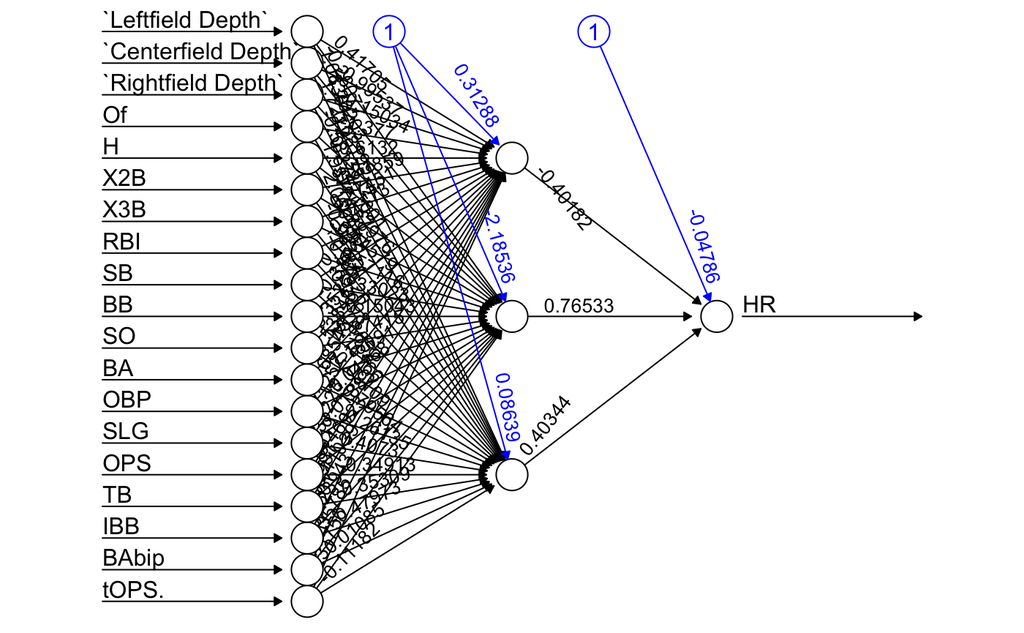

```r
set.seed(3432)
trainNN <- scaledNeuralDF[sampler, ]
testNN <- scaledNeuralDF[-sampler, ]
neural <- neuralnet(formula = HR ~ `Leftfield Depth` + `Centerfield Depth` + `Rightfield Depth` + Of + H + X2B + X3B + RBI + SB + BB + SO + BA + OBP + SLG + OPS + TB + IBB + BAbip + tOPS., trainNN, hidden = 3 , linear.output = T )
plot(neural)
```

Uses neural network created above using the training data to predict the homerun values for the stadiums in the testing data set. Plots the accuracy of the model on the test data below.

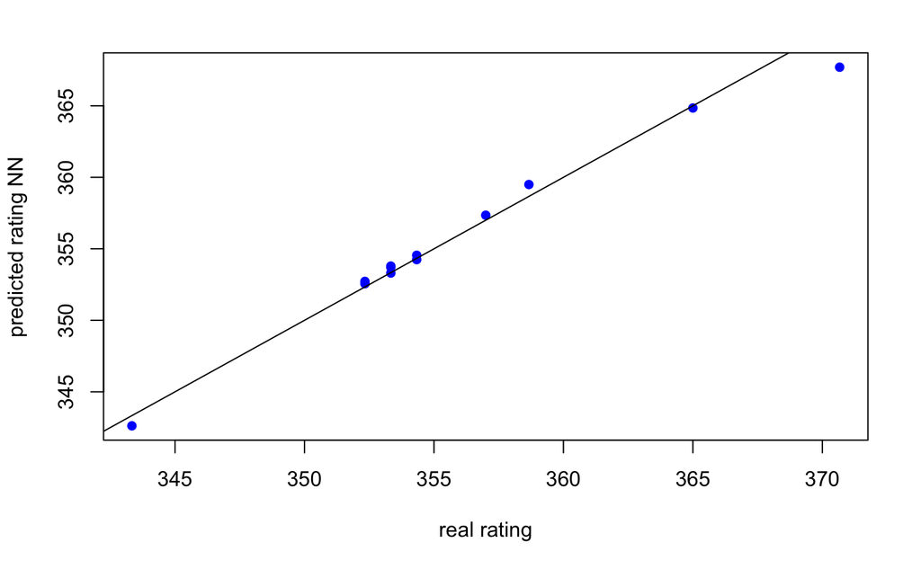

```r
set.seed(4576)
predictTestNN <- compute(neural, testNN[, c("Leftfield Depth", "Centerfield Depth", "Rightfield Depth", "Of", "H", "X2B", "X3B", "RBI", "SB", "BB", "SO", "BA", "OBP", "SLG", "OPS", "TB", "IBB", "BAbip", "tOPS.")])
predictTestNN <- (predictTestNN$net.result * (max(neuralDF$HR) - min(neuralDF$HR))) + min(neuralDF$HR)
{plot(neuralTest$HR, predictTestNN, col='blue', pch=16, ylab = "predicted rating NN", xlab = "real rating")
abline(a=0,b=1)}
```

Calculates the mean squared error for the test predictions plotted on the graph above.

```r
MSEnn = (sum((neuralTest$HR - predictTestNN)^2) / nrow(neuralTest)) ^ 0.5
print(MSEnn)
```

```
[1] 0.9468366937
```

```r
averageHR <- mean(neuralTest$HR)
pctMSEnn <- MSEnn/averageHR
print(pctMSEnn)
```

```
[1] 0.00266214628
```